# Practical Machine Learning - Project

ElData

Thursday, September 18, 2014

```r
library(knitr)
knitr::opts_chunk$set(error = TRUE)
```

## Executive Summary:

A classification model was fitted from a set of train/test data from over 19000 samples with up to 160 variables. More information on the study and data source is available here: http://groupware.les.inf.puc-rio.br/har (see the section on the Weight Lifting Exercise Dataset).

The final reslults were achieved by training/testing a predictive model utilizing the **Random Forest** method and a **four fold cross validation**. The **“In Sample” accuracy** measured was 100% and the **“Out of Sample” accuracy** measured was 99.58% . And ultimately, the prediction model running the testing data provided by the instructor yielded a **prediction of 20/20 correct or 100%**.

## Retrieve the data:

```r
traincsv<-"http://d396qusza40orc.cloudfront.net/predmachlearn/pml-training.csv"
testcsv<-"http://d396qusza40orc.cloudfront.net/predmachlearn/pml-testing.csv"
download.file(traincsv, destfile = "pml-training.csv", method = "auto")
download.file(testcsv, destfile = "pml-testing.csv", method = "auto")
```

## Load the data:

```r
training <- read.table("./pml-training.csv",sep=",",na.strings = c("NA",""),header=TRUE)
testing <- read.table("./pml-testing.csv",sep=",",na.strings = c("NA",""),header=TRUE)
```

## Process and clean data:

Check for (1)total number of NAs in the dataset, then; (2)total NAs in each “training” and “testing” datasets.

```r
sum(is.na(training))
```

```
## [1] 1921600
```

```r
na_train <- sapply(training, function(x) {sum(is.na(x))})
table(na_train)
```

```
## na_train
##     0 19216
##    60   100
```

```r
na_test <- sapply(testing, function(x) {sum(is.na(x))})
table(na_test)
```

```
## na_test
##   0  20
##  60 100
```

Clean the data as follows:

```r
# For Training dataset:
columnNACounts <- colSums(is.na(training))         # get NA counts for all columns
badColumns <- columnNACounts >= 19000              # ignore columns with mostly NA values
cleanTrainingdata <- training[!badColumns]         # get clean data
sum(is.na(cleanTrainingdata))                      # check for NA values
```

```
## [1] 0
```

```r
cleanTrainingdata <- cleanTrainingdata[, c(7:60)]  # remove unnecessary columns

# For Testing dataset:
columnNACounts <- colSums(is.na(testing))       # get NA counts for all columns
badColumns <- columnNACounts >= 20              # ignore coluns with mostly NA values
cleanTestingdata <- testing[!badColumns]        # get clean data
sum(is.na(cleanTestingdata))                    # check for NA values
```

```
## [1] 0
```

```r
cleanTestingdata <- cleanTestingdata[, c(7:60)] # remove unnecessary soumns
```

Dataset is now clean of NA values and some unnecessary variables were removed.

## Exploratory Data Analysis:

We take a look at summary statistics and frequency plot for the “classe” variable.

```r
summary(cleanTrainingdata$classe)
```

```
##    A    B    C    D    E
## 5580 3797 3422 3216 3607
```

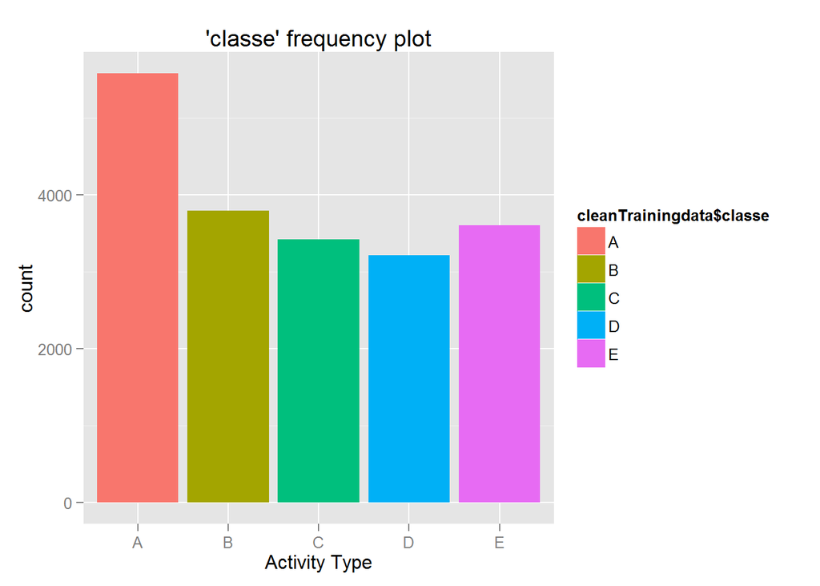

```r
library(ggplot2)
qplot(cleanTrainingdata$classe, geom="histogram", fill=cleanTrainingdata$classe, main="'classe' frequency plot", xlab="Activity Type")
```

## Build Model:

Build machine learning model for prediction of the “classe” value based on the other features of the dataset. Data partitioning - We partition the cleanTrainingdata dataset into training and testing datasets, respectively to build our model.

```r
library(caret)
set.seed(368)
inTrain <- createDataPartition(y=cleanTrainingdata$classe, p=0.6, list=FALSE)
trainingdata <- cleanTrainingdata[inTrain, ]
testingdata <- cleanTrainingdata[-inTrain, ]
dim(trainingdata)
```

```
## [1] 11776    54
```

**Model Building:** We now use our trainingdata dataset to build our model using the **Random Forest** machine learning technique and using 4 fold cross validation.

```r
library(foreach)
library(doParallel)  # run model in parallel using all 4 cores of intel i7 3517 CPU on/windows7 (~13 mins).
registerDoParallel(cores=4)
model <- train(trainingdata$classe ~., data=trainingdata, method="rf", prox=TRUE,
               trControl=trainControl(method="cv", number=4, allowParallel=TRUE))
print(model)
```

```
## Random Forest
##
## 11776 samples
##    53 predictor
##     5 classes: 'A', 'B', 'C', 'D', 'E'
##
## No pre-processing
## Resampling: Cross-Validated (4 fold)
##
## Summary of sample sizes: 8831, 8833, 8831, 8833
##
## Resampling results across tuning parameters:
##
##   mtry  Accuracy  Kappa  Accuracy SD  Kappa SD
##    2    1         1      8e-04        0.001
##   27    1         1      1e-03        0.002
##   53    1         1      2e-03        0.003
##
## Accuracy was used to select the optimal model using  the largest value.
## The final value used for the model was mtry = 27.
```

## In Sample accuracy:

We calculate the “in sample” accuracy which is the prediction accuracy of our model on the training dataset.

```r
training_pred <- predict(model, trainingdata)
confusionMatrix(training_pred, trainingdata$classe)
```

```
## Confusion Matrix and Statistics
##
##           Reference
## Prediction    A    B    C    D    E
##          A 3348    0    0    0    0
##          B    0 2279    0    0    0
##          C    0    0 2054    0    0
##          D    0    0    0 1930    0
##          E    0    0    0    0 2165
##
## Overall Statistics
##
##                Accuracy : 1
##                  95% CI : (1, 1)
##     No Information Rate : 0.284
##     P-Value [Acc > NIR] : <2e-16
##
##                   Kappa : 1
##  Mcnemar's Test P-Value : NA
##
## Statistics by Class:
##
##                      Class: A Class: B Class: C Class: D Class: E
## Sensitivity             1.000    1.000    1.000    1.000    1.000
## Specificity             1.000    1.000    1.000    1.000    1.000
## Pos Pred Value          1.000    1.000    1.000    1.000    1.000
## Neg Pred Value          1.000    1.000    1.000    1.000    1.000
## Prevalence              0.284    0.194    0.174    0.164    0.184
## Detection Rate          0.284    0.194    0.174    0.164    0.184
## Detection Prevalence    0.284    0.194    0.174    0.164    0.184
## Balanced Accuracy       1.000    1.000    1.000    1.000    1.000
```

We see from above output that our “in sample” accuracy value is 1 or 100%.

## Out of Sample accuracy:

We calculate the “out of sample” accuracy which is the prediction accuracy of our model on the testing dataset.

```r
testing_pred <- predict(model, testingdata)
confusionMatrix(testing_pred, testingdata$classe)
```

```
## Confusion Matrix and Statistics
##
##           Reference
## Prediction    A    B    C    D    E
##          A 2232    8    0    0    0
##          B    0 1506   11    0    0
##          C    0    3 1354    6    0
##          D    0    1    3 1280    1
##          E    0    0    0    0 1441
##
## Overall Statistics
##
##                Accuracy : 0.996
##                  95% CI : (0.994, 0.997)
##     No Information Rate : 0.284
##     P-Value [Acc > NIR] : <2e-16
##
##                   Kappa : 0.995
##  Mcnemar's Test P-Value : NA
##
## Statistics by Class:
##
##                      Class: A Class: B Class: C Class: D Class: E
## Sensitivity             1.000    0.992    0.990    0.995    0.999
## Specificity             0.999    0.998    0.999    0.999    1.000
## Pos Pred Value          0.996    0.993    0.993    0.996    1.000
## Neg Pred Value          1.000    0.998    0.998    0.999    1.000
## Prevalence              0.284    0.193    0.174    0.164    0.184
## Detection Rate          0.284    0.192    0.173    0.163    0.184
## Detection Prevalence    0.285    0.193    0.174    0.164    0.184
## Balanced Accuracy       0.999    0.995    0.994    0.997    1.000
```

We see from above output that our “out of sample” accuracy value is 0.9958 or 99.58%.

## Prediction Assignment:

We apply the our machine learning algorithm to each of the 20 test cases in the testing dataset provided to us.

```r
answers <- predict(model, cleanTestingdata)
answers <- as.character(answers)
answers
```

```
##  [1] "B" "A" "B" "A" "A" "E" "D" "B" "A" "A" "B" "C" "B" "A" "E" "E" "A"
## [18] "B" "B" "B"
```

As requested, we now write the answers to .txt file(s) using the following code as provided:

```r
pml_write_files = function(x) {
        n = length(x)
        for(i in 1:n) {
                filename = paste0("problem_id", i, ".txt")
                write.table(x[i], file = filename, quote = FALSE, row.names = FALSE,
                            col.names = FALSE)
        }
}
pml_write_files(answers)
```

And ultimately, the prediction model running the testing data provided by the instructor yielded a **prediction of 20 out of 20 correct or 100%**.